# 慶應通信成績まとめ

Apr,2018～Mar,2023

Created at 2023/03/11

## 科目区分ごとの取得単位数とGPA

| 区分 | 単位数 | GPA |
| --- | --- | --- |
| 認定単位 | 18 | NA |
| 総合教育科目 | 32 | 3.34 |
| 専門教育科目 | 68 | 3.22 |
| 必修科目 | 29 | 3.31 |
| 選択科目 | 71 | 3.24 |
| テキスト | 60 | 3.18 |
| スクーリング | 40 | 3.38 |
| 対面試験 | 26 | 3.42 |
| 代替試験 | 74 | 3.20 |
| 卒論 | 8 | 4.00 |
| 取得単位計 | 108 | 3.31 |

**区分の説明**

必修科目：英語,統計学(A),経済学部必修科目  
選択科目：卒論を除く必修科目以外の科目  
対面試験：オフラインスクーリング含む  
代替試験：オンラインスクーリング含む

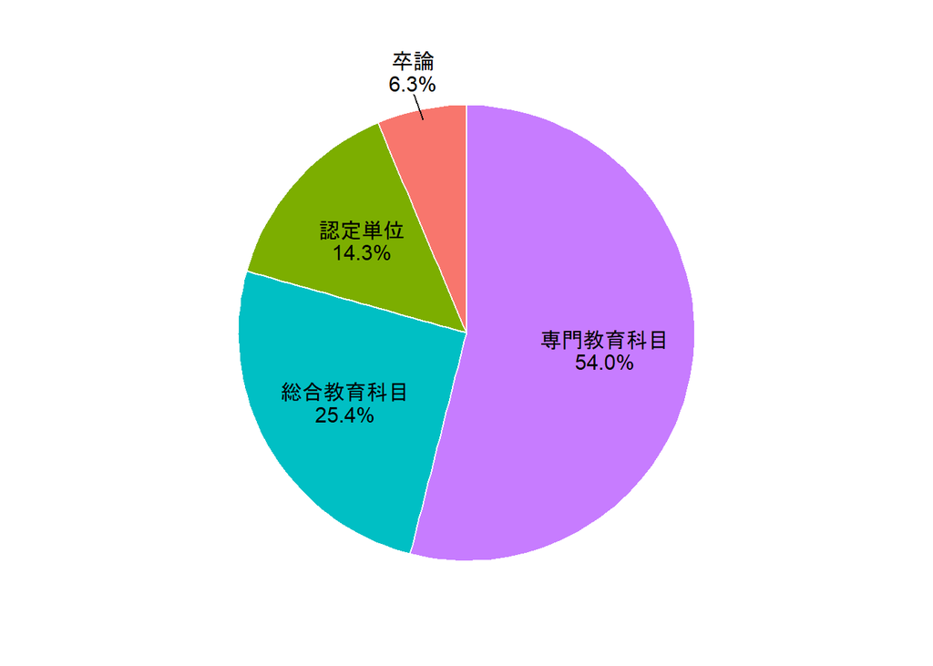

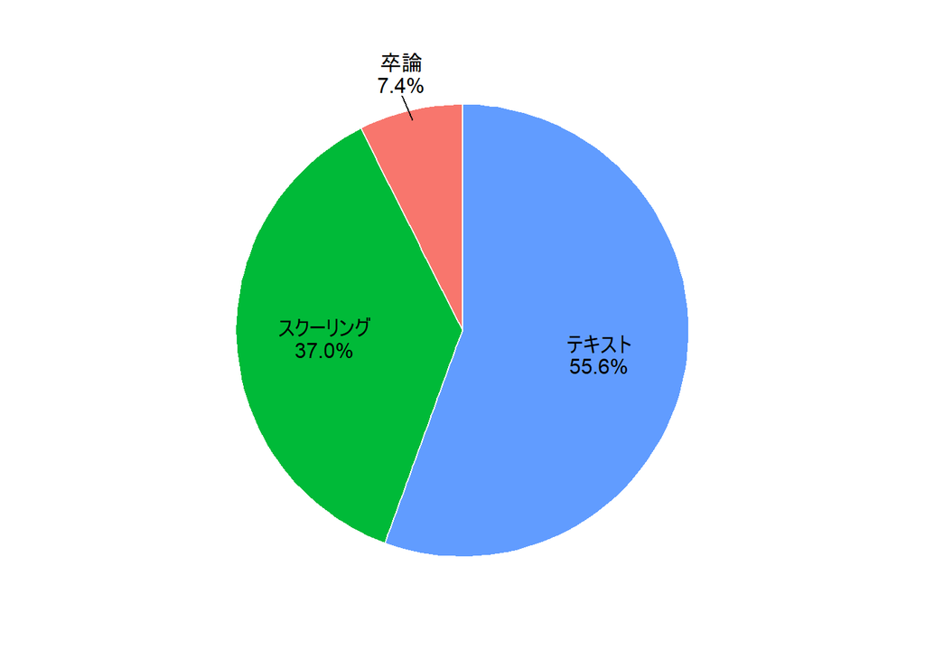

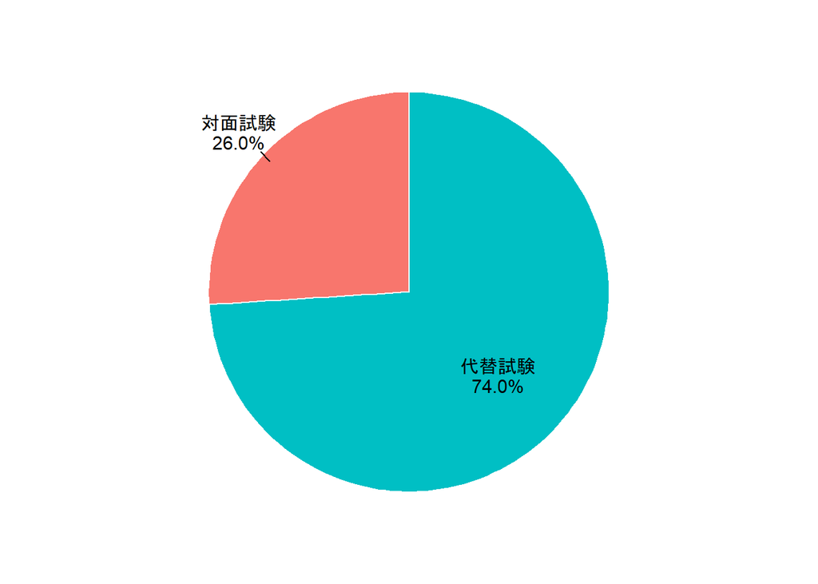

## 科目群ごとの取得単位数とGPA(群があるもののみ)

| 科目群 | 単位数 | GPA |
| --- | --- | --- |
| A群 | 9 | 2.78 |
| B群 | 17 | 3.29 |
| C群 | 10 | 2.80 |
| D群 | 12 | 3.50 |
| E群 | 9 | 3.00 |
| F群 | 9 | 3.67 |

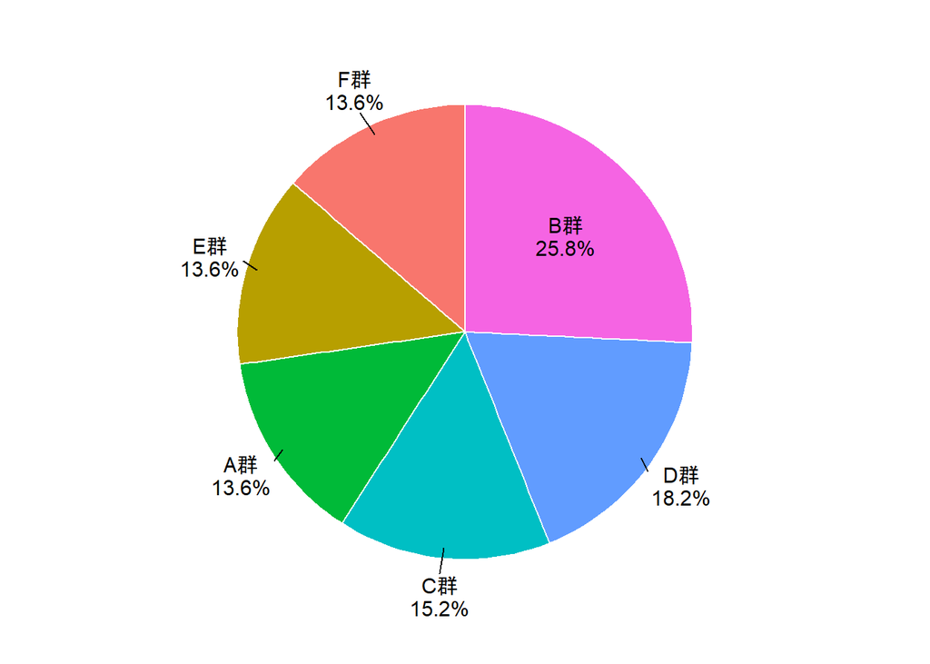

**所見**

代替の方が成績が良いと思ったら意外とそうでもなかった。でもやはりテキストよりスクーリングの方が好成績を取りやすい。  
また総合科目より専門科目の方が難しかったのは成績にも表れている。  
必修は全体的にそこそこいい成績だったので嬉しい。 ただ評価の基準は相変わらずよくわからん。予想より悪かったのはたくさんあるが、予想より良かったことはない。特に数学(基礎)なんて「これ絶対100点じゃん、あざーす」からのＢなのでマジでわからん。

## スクーリングごとの取得単位数とGPA

| 区分 | 単位数 | GPA |
| --- | --- | --- |
| 夏スク | 28 | 3.32 |
| 週末スク | 8 | 3.50 |
| 夜スク | 2 | 4.00 |
| Eスク | 2 | 3.00 |

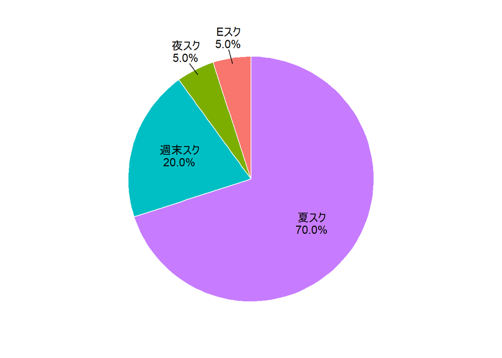

**所見**

夜スク>週末スク>夏スクの順に予習復習の時間が確保しやすい分成績が良くなる気がする。  
ただ夜スクは1回しか受けてないが個人的に12回も通学するのは通信なのにコスパが悪いと感じた。

## 成績ごとの取得単位数と比率

| 評価 | 単位数 |
| --- | --- |
| S (秀) | 47 |
| A (優) | 50 |
| B (良) | 9 |
| C (可) | 2 |
| D (不可) | 0 |

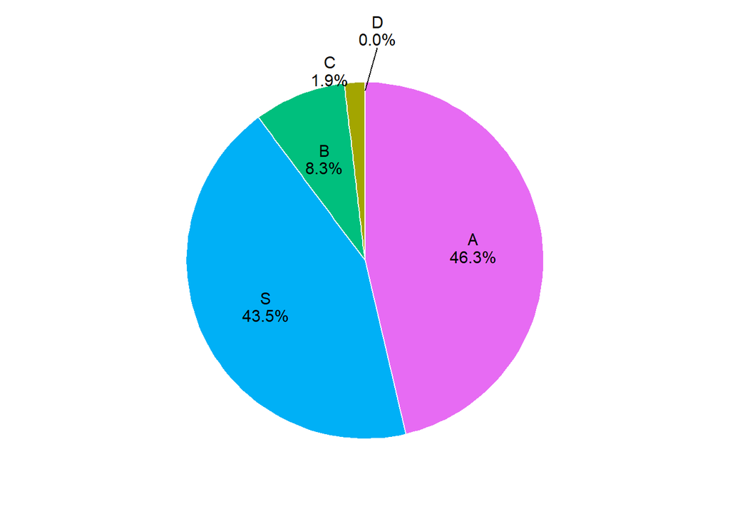

**所見**

約9割がSとAだったのはまあ良かった。やはりB,C,Dをいかに少なく抑えるかが高GPA維持のポイントか。  
この私に唯一のCを付けていただいた夏スク財〇論のS村先生、全然恨んでないですよw

## 年度ごとの取得単位数とGPA

| 年度 | 単位数 | GPA |
| --- | --- | --- |
| 1 年目 | 8 | 3.50 |
| 2 年目 | 16 | 3.31 |
| 3 年目 | 28 | 3.21 |
| 4 年目 | 42 | 3.21 |
| 5 年目 | 14 | 3.71 |

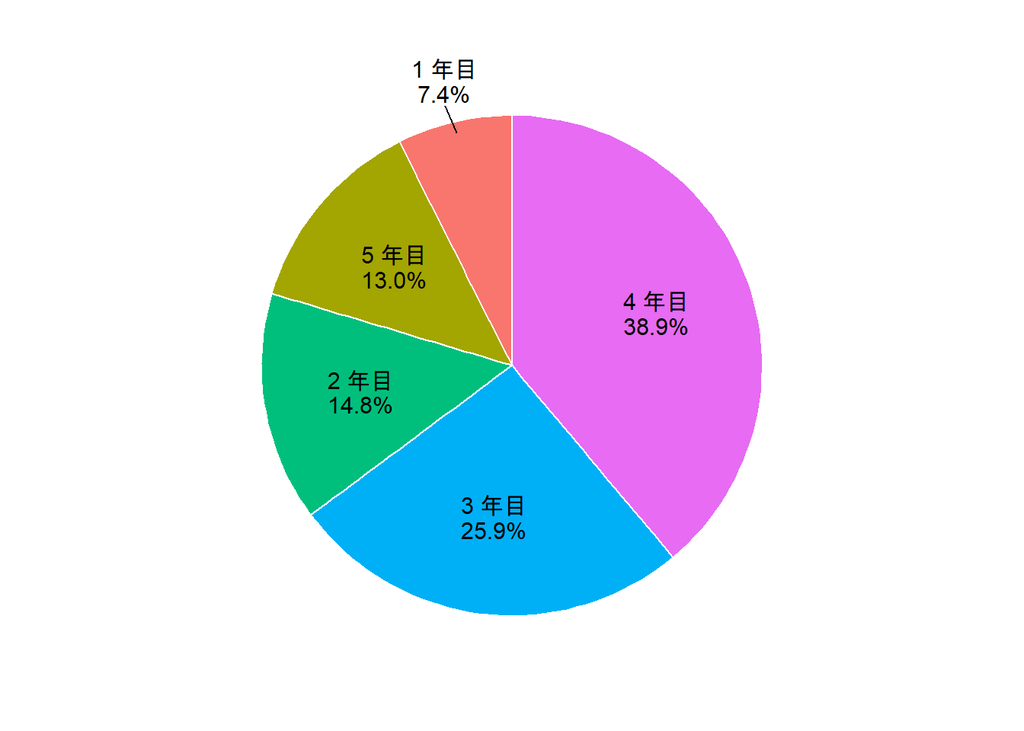

**所見**

1年目はスクーリングと英語2の8単位だけ。2年目の最後あたりから代替レポが開始。代替が無かったらこのままドロップアウトしていたと思われる。3,4年目で単位を荒稼ぎし最終年は微調整って感じ。まあそれでも5年かかっているので仕事しながら最短で卒業する人は超人か神。

## 取得単位数とGPAの推移

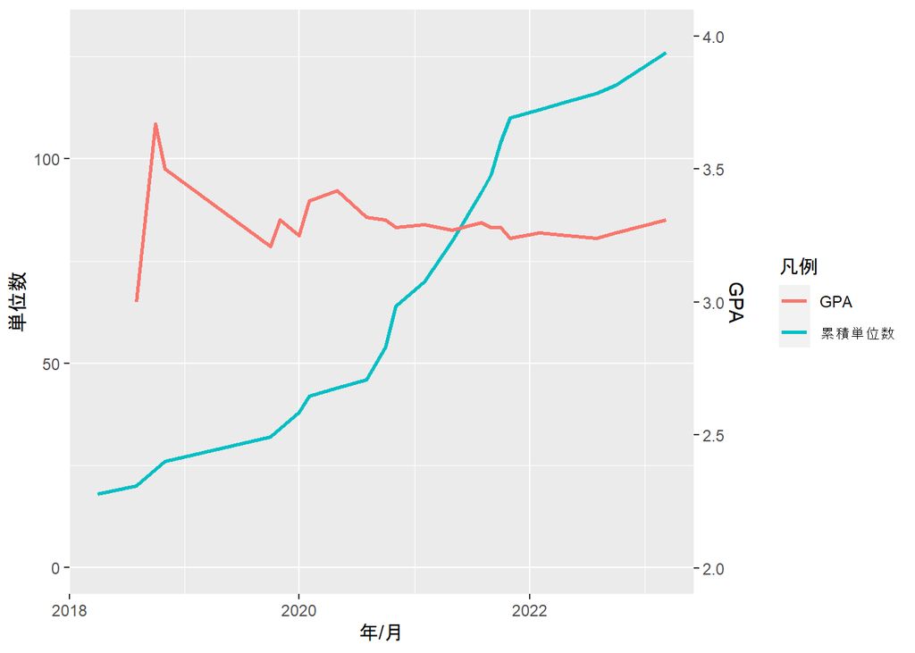

**所見**

当たり前だが単位の少ないうちは母数が少ないのでGPAが乱高下し単位増加に伴い収束する。

## 科目試験不合格回数ランキング

| 順位 | 科目名 | 不合格回数 |
| --- | --- | --- |
| 1 | 英語Ⅰ | 3 |
| 2 | 数学(基礎) | 2 |
| 2 | 経済原論（マクロ経済学）（Ｅ） | 2 |
| 4 | 英語Ⅶ | 1 |
| 4 | 金融論（Ｅ） | 1 |

**所見**

英語1と数学の不合格はすべて対面試験。それ以外は代替試験。やはり代替は合格率は高い。代替で不合格になった科目は代替になってから難化した科目？知らんけど。

## レポート不合格回数ランキング

| 順位 | 科目名 | 分冊 | 不合格回数 |
| --- | --- | --- | --- |
| 1 | 論理学（A） |  | 2 |
| 1 | 数学(基礎) | 第1回 | 2 |
| 3 | 統計学（A） | 第1回 | 1 |
| 3 | 英語Ⅰ | 第2回 | 1 |
| 3 | 金融論（Ｅ） |  | 1 |
| 3 | 原価計算 |  | 1 |
| 3 | 経営数学 |  | 1 |
| 3 | 経済変動論 |  | 1 |

**所見**

## レポート返却日数ランキング

### BEST5

[output not shown]

### WORST5

| 順位 | 科目名 | 分冊 | 提出回 | 返却日数 | 結果 |
| --- | --- | --- | --- | --- | --- |
| 1 | 論理学（A） |  | 3回目 | 55 days | 合格 |
| 2 | 社会保障論（Ｅ） |  | 1回目 | 46 days | 合格 |
| 3 | 統計学（A） | 第1回 | 2回目 | 45 days | 合格 |
| 4 | 財政論（Ｅ） |  | 1回目 | 41 days | 合格 |
| 5 | 論理学（A） |  | 2回目 | 40 days | 不合格 |

**所見**

最長でも2か月弱で返却されているのでそれほど待たされたという感じはしなかった。恐らく時期によって採点者が忙しいとかいろいろな要素はあると思う。いずれにせよさんざん待たされた挙句にFGKはへこむ。

Powered by [kccStats](https://github.com/dskyshr/kccstats)